# Trends - statistical tests

data busteRs

season 2 / episode 14  
All rights reserved.  
Usage allowed only with the author's permission.  
Press `A` to turn slides into full text.  
Press `T` to show Table of Contents.

# What is this episode about?

In last episode we have learned the method for determining linear trend factors.

This allows us to, for example, assess whether any observed parameter increases or decreases on average.

However, sometimes the rating of the factor $a_1$, describing the growth pace is very close to the $0$ value. We can then ask additional question of whether the observed growth is not the result of random fluctuations?

How to answer this question? When is the observed trend random, and when is it not?

Here, statistics can once again help us. Using such tools as *trend factor test* we can assess to what degree is the value of the growth factor not random.

In this episode, using data from IMDB (Internet Movie Database) website, we'll show how the procedure of testing the data trend works.

# Data set for work

In the IMDB movie database (Internet Movie Database) one can find different data concerning TV series, in particular, the average user ratings issued for subsequent episodes of the series.

For example no the http://www.imdb.com/title/tt0903747/epdate?ref_=ttep_ql_4 website there are ratings for *Breaking Bad* TV series.

We have downloaded this data from the Internet, and prepared them so they would be available in a dataset `serialeIMDB` in a packet `PogromcyDanych`, which was attached to this course.

From this data set we'll only pick values for the `Breaking Bad` TV series.

```r
library(PogromcyDanych)
# wybieramy dane o jednym serialu, dwie kolumny
tylkoBreakingBad <- serialeIMDB %>% filter(serial == "Breaking Bad") %>% select(id, ocena)
# wyświetlamy pierwsze wiersze
head(tylkoBreakingBad)
```

```
##   id ocena
## 1  1   8.7
## 2  2   8.2
## 3  3   8.3
## 4  4   7.9
## 5  5   7.9
## 6  6   8.7
```

# Data and linear trend

In the last episode we have shown how to determine linear trend factors in the R program with `lm()` function. To recall, to receive the starting point of the trend, and the rate of change per episode, it was necessary to use the instruction.

```r
lm(ocena~id, tylkoBreakingBad)$coef
```

```
## (Intercept)          id
##  7.90222105  0.01836267
```

# Is the rating growth for Breaking Bad a coincidence? Permutation test

For the Breaking Bad TV series we observe a growth tendency of over 0.018.

Can this tendency persuade us that the subsequent episodes of this series are gradually better (in any event, gradually higher rated)?

Statisticians have developed a number of tests aimed at assessing the significance of a trend / tendency. In most cases those tests provide us with similar results, so instead of presenting a lexicon of them, we'll use one example to clarify how the testing works. We'll present so called permutation test for trend assessment.

Idea for assessment whether the trend has a significant growth tendency consists of three steps. We'll present them one by one.

### Step 1: Formulate a hypothesis, specify what do you want to compare

We'll be testing a hypothesis (=assumption) whether the growth factor is significantly different from zero, which means no trend.

Let's formulate this hypothesis as follows: *Is the observed growth factor value large enough to consider it a significant one?*

### Step 2: Specify the value measure

Let's assume that the growth factor value will be measured with the absolute value of this factor. Both the strong negative as well as a strong positive trend will be deemed as other than zero.

The absolute value can be determined with `abs()` function.

```r
(wspolczynnikiTrendu <- lm(ocena~id, tylkoBreakingBad)$coef)
```

```
## (Intercept)          id
##  7.90222105  0.01836267
```

```r
# moduł współczynnika wzrostu
(modulBreakingBad <- abs(wspolczynnikiTrendu[2]))
```

```
##         id
## 0.01836267
```

# Is the rating growth for Breaking Bad a coincidence? Permutation test

### Step 3: Compare the trend observed with a trend in a situation where there is no dependence.

We still don't know whether `0.0183` is a big or small growth.

We have to compare it to something. It would be best to compare it with the values that we would have observed if there were no real trend.

But how do we know what value would this factor have if there was no trend? We can estimate in as follows

- [I] We'll randomly mix ratings values. As a result we obtain ratings sequence which we know does nor display any systematic trend (random mixing), and potential size of the trend factor results from random fluctuations,
- [II] We'll calculate how large is the trend for newly created groups,
- [III] We'll repeat steps [I] and [II] multiple times to check how large are the values which can be assumed by a trend, when it is a result of random fluctuations. Let's repeat those steps multiple times, e.g. 99999 times.

This calculation of the trend value for randomly mixed data is executed by the following code.

```r
# funkcja replicate() powtarza drugie wyrażenie tyle razy, ile wynosi pierwszy argument (=99999)
trendy <- replicate(99999, {
  # wymieszaj losowo wartości, robi to funkcja sample()
  tylkoBreakingBad$wymieszane <- sample(tylkoBreakingBad$ocena)

  # wyznacz moduł współczynnika wzrostu dla losowo wymieszanych danych
  wspolczynnikiTrendu <- lm(wymieszane~id, tylkoBreakingBad)$coef
  abs(wspolczynnikiTrendu[2])
})
# modulBreakingBad jest też jedną z możliwych permutacji, dodajmy go do wyniku
trendy <- c(trendy, modulBreakingBad)
# wyświetl pierwsze 20 z tak otrzymanych wartości
head(trendy, 20)
```

```
##           id           id           id           id           id
## 4.326257e-03 1.631790e-03 3.223288e-04 1.913827e-04 2.996651e-03
##           id           id           id           id           id
## 1.092896e-03 3.157815e-03 7.171816e-03 3.525472e-05 2.558485e-03
##           id           id           id           id           id
## 7.050943e-05 6.683287e-03 5.645791e-03 2.659213e-03 5.842210e-04
##           id           id           id           id           id
## 1.203697e-03 5.333535e-03 3.248470e-03 8.461132e-04 8.934552e-03
```

# Is the rating growth for Breaking Bad a coincidence? Values comparison

Now we can compare `modulBreakingBad` value with referential values vector - `trendy`.

The `trendy` vector may be considered to be values of growths, which we can expect when samples differ only by the random variability. If `modulBreakingBad` was significantly larger than values of the `trendy` vector, it would be a strong argument that the growth trend in the ratings of *Breaking Bad* episodes is not a coincidence.

On the plot, let's compare the difference values for random fluctuations (in gray) with the observed difference (in red).

As we can see, the observed ratings growth value for the *Breaking Bad* series is much greater than the growths that we would see if there was no real trend.

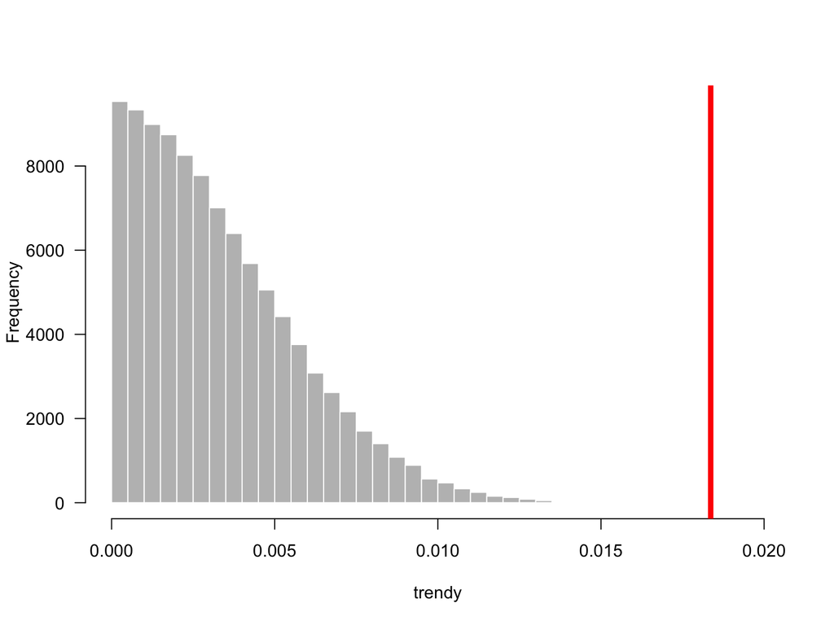

```r
# jak wyglądają przypadkowe współczynniki
hist(trendy, 50, col="grey", main="", las=1, border="white", xlim=c(0, 0.02))
# dorysuj na czerwono gdzie jest współczynnik dla BreakingBad
abline(v=modulBreakingBad, col="red", lwd=5)
```

# Is the rating growth for Breaking Bad a coincidence? P-value

The plot helps to notice how the random factors look against the observed values.

However, to make a decision it is better to have one number. What number?

Let's calculate what proportion of the trends for random fluctuation is greater or equal to the observed trend for *Breaking Bad*. This value is called value-p or p-value.

```r
# p-wartość
mean(trendy >= modulBreakingBad)
```

```
## [1] 1e-05
```

Only 0.00001? Thus, when we randomly distorted the ratings we were not able to acquire growth as large as it was in case of *Breaking Bad*. This single value by which the observed mean value differs from zero is a result of a trend observed without permutation, which we added to the vector `trendy`.

This comparison which shows how large is the `modulBreakingBad` value against random `trendy` is a convincing argument for hypothesis that the observed rating growth of *Breaking Bad* is not coincidental.

# But what about Friends?

How does the trend look like for the *Friends* series?

When it comes to value, it is barely over 0.000432, which means it is positive, but smaller than that of Breaking Bad.

Hypotheses which we want to check is whether this trend is indeed bigger than zero.

```r
tylkoFriends <- serialeIMDB %>% filter(serial == "Friends") %>% select(id, ocena)
# wyznaczmy współczynniki trendu liniowego dla serialu Przyjaciele
lm(ocena~id, tylkoFriends)$coef
```

```
##  (Intercept)           id
## 8.4562918838 0.0004325633
```

# But what about Friends? Testing

We'll verify the hypothesis on significance of the trend in the same way as for the *Breaking Bad* series.

Let's conduct the same calculations and compare the results in the same way as before.

```r
# trend dla serialu Friends
wspolczynnikiTrendu <- lm(ocena~id, tylkoFriends)$coef
(modulFriends <- abs(wspolczynnikiTrendu[2]))
```

```
##           id
## 0.0004325633
```

```r
# losowe współczynniki trendu w liczbie 99 999
trendy <- replicate(99999, {
  tylkoFriends$wymieszane <- sample(tylkoFriends$ocena)
  wspolczynnikiTrendu <- lm(wymieszane~id, tylkoFriends)$coef
  abs(wspolczynnikiTrendu[2])
})
# modulFriends jest też jedną z możliwych permutacji, dodajmy go do wyniku
trendy <- c(trendy, modulFriends)
head(trendy, 20)
```

```
##           id           id           id           id           id
## 3.520056e-04 3.724788e-04 4.102208e-04 4.762246e-06 4.998133e-05
##           id           id           id           id           id
## 1.644533e-04 3.436383e-04 1.112674e-06 8.154122e-04 5.069789e-04
##           id           id           id           id           id
## 3.659808e-04 4.654984e-04 3.947768e-05 5.256273e-05 8.380663e-05
##           id           id           id           id           id
## 6.048497e-05 4.395954e-04 2.730503e-04 7.417087e-04 1.558189e-04
```

We have determined a reference growth vector `trendy`. How does the observer 0.00043 look against it?

# But what about Friends? Testing

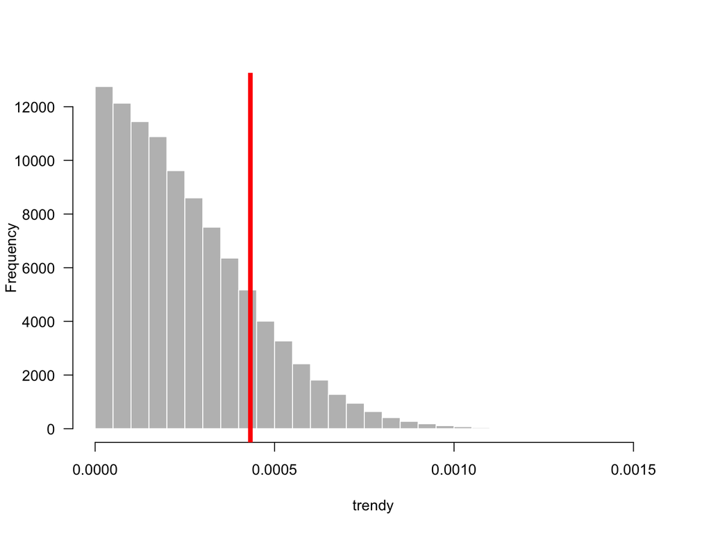

```r
# wykres z wartościami referencyjnymi i wzrostem dla serialu Przyjaciele
hist(trendy, 50, col="grey", main="", las=1, border="white")
abline(v=modulFriends, col="red", lwd=5)
```

# But what about Friends? P-value

Graphic assessment already tells us that we are dealing with a different situation. This time, it is quite often the case that the random vector permutations result in ratings growth factor greater than that observed for the Friends series.

How to describe those diifferences with one number?

```r
# jak często obserwuje się wartość większą lub równą
# p-wartość
mean(trendy >= modulFriends)
```

```
## [1] 0.17215
```

For the *Friends* series, even when we randomly select the ratings, in more than 17 percent we observe the trend greater than `0.00043`. Does it mean that the growth trend is purely coincidental?

There is no certainty, but we are rather inclined to conclude that this trend is not significantly different from zero.

The threshold is often assumed to be 0.05 (mainly for historical reasons, but it is common). It means that the trend is considered to be non-random if it is smaller by maximum 5% of the value that can be observed randomly (one in 20).

Assuming the threshold of 0.05, p-value which we observe for the trend of the Friends season is higher, thus we assume the hypothesis that this trend is not significantly different than zero.

# Testing summary

The results which we acquired for the *Breaking Bad* series are different than those of the *Friends* series.

In case of *Breaking Bad* series we have tried 99999 times to randomly mix data in order to observe a bigger growth on mixed data than on the original order. It was not successful, which persuaded us that the trend observed for *Breaking Bad* is *significantly greater than coincidental (=0)*.

In case of the *Friends* series we have tried the same. The only difference is that we quite often managed to acquire, by random permutations, values greater than for the original sequence.

The statistic describing what proportion of the randomly generated trends is greater than the observed trend is called the p-value. We have also assumed that if the p-value is small, e.g. less than 0.05 (arbitrary choice, but the accepted one) we will assume that the trend is significant.

However, for the *Friends* series the observed p-value is significantly larger, which is why we shall assume that the trend is not significantly different from coincidental (=0)

# Summary of R instructions

In this episode we discussed the functions used to test the linear trend.

```r
library(PogromcyDanych)
# wybieramy dane o jednym serialu, dwie kolumny
tylkoBreakingBad <- serialeIMDB %>% filter(serial == "Breaking Bad") %>% select(id, ocena)
# wyświetlamy pierwsze wiersze
head(tylkoBreakingBad)

# liczymy współczynniki trendu
lm(ocena~id, tylkoBreakingBad)$coef

(wspolczynnikiTrendu <- lm(ocena~id, tylkoBreakingBad)$coef)
# moduł / wartość bezwzględna współczynnika wzrostu
(modulBreakingBad <- abs(wspolczynnikiTrendu[2]))

# funkcja replicate() powtarza drugie wyrażenie tyle razy, ile wynosi pierwszy argument (=99999)
trendy <- replicate(99999, {
  # wymieszaj losowo wartości, robi to funkcja sample()
  tylkoBreakingBad$wymieszane <- sample(tylkoBreakingBad$ocena)
  # wyznacz moduł współczynnika wzrostu dla losowo wymieszanych danych
  wspolczynnikiTrendu <- lm(wymieszane~id, tylkoBreakingBad)$coef
  abs(wspolczynnikiTrendu[2])
})
# modulBreakingBad jest też jedną z możliwych permutacji, dodajmy go do wyniku
trendy <- c(trendy, modulBreakingBad)
# wyświetl pierwsze 20 z tak otrzymanych wartości
head(trendy, 20)

# jak wyglądają przypadkowe współczynniki
hist(trendy, 50, col="grey", main="", las=1, border="white", xlim=c(0, 0.02))
# dorysuj na czerwono gdzie jest współczynnik dla BreakingBad
abline(v=modulBreakingBad, col="red", lwd=5)

# p-wartość dla tetstu
mean(trendy >= modulBreakingBad)
```

# Tasks

- Find a series with a significant negative trend, which means the one in which ratings drop.
- Find a series (other than *Breaking Bad*) with a significant positive trend.
- [Difficult] Calculate for how many TV series their ratings grow and for how many they drop, and such growths or drops are significantly larger than coincidental.